# 03_Analysis

2025-02-04

# Analyse de données

## Quelles analyses mener?

1. Etude des valeurs manquantes
2. Etude des distributions des variables clés
3. Analyse de corrélation entre variables
4. Analyse multivariées

```r
# Nettoyer l'espace
rm(list = ls()) # Enlève tout ce qu'il y a dans l'environnement

library(dplyr)
library(tidyr)
library(magrittr)
library(factoextra)
library(FactoMineR)
library(reshape2)
library(readxl)
library(openxlsx)
library(here)
renv::snapshot()
```

```
## - The lockfile is already up to date.
```

```r
data_ = read.xlsx(here('data', 'processed', 'data_cleaned.xlsx'))

data_$classe_age = factor(data_$classe_age,
                          levels = c("<20 ans","20-35 ans","35-50 ans",
                                     "50-65 ans", ">65 ans"))

to_factor_vect =  c(colnames(data_)[c(startsWith(colnames(data_), 'phoque_'))],
                    colnames(data_)[c(startsWith(colnames(data_), 'q_'))],
                    c("pêche):", "chasse","voile","vélo","natation", "planceàvoile" ,"paddle","kayak/canoë",
                      "kitesurf","equitation","wingfoil","promenade","marche","naturaliste","Autre" ))
to_factor_vect=to_factor_vect[to_factor_vect != 'nom_phoques']

data_ = data_ %>%
  mutate(across(all_of(to_factor_vect), as.factor))
```

## Analyses simples

Pour cela, on va utiliser la bibliothèque `ggplot2` (Grammar of Graphics) qui prend les éléments suivants :

- Les données (`data`)
- Les “aesthetics” (`aes()`) : comment représenter les variables, qui est en abscisse (`x=`), en ordonnée (`y=`), en couleur (`color=`)
- La géométrie (`geom()`): le type de graphique
- Une variété d’éléments de style :
  - `scale_color_`, `scale_fill` pour les couleurs
  - `theme()` pour les axes, polices, tailles, couleur de fond
- On peut également représenter sur différents panels avec les fonctions `facet_`
- Marche au mieux lorsque les données sont sous le format `tidy`: une variable par colonne, une observation par ligne
  - On utilise parfois `pivot_longer()` pour transformer des données “larges” en “longues”, pour tout représenter d’un coup

## Les variables démographiques

### Code

```r
custom_theme = function(){
  theme_minimal() +  # Base theme
  theme(
    axis.text.x = element_text(angle = 45, hjust = 1),  # Rotate x-axis labels by 45 degrees
    legend.position = "bottom"
  )
}

p = data_ %>%
  select(c('genre', 'classe_age','date', 'professions', 'lieu')) %>%
  pivot_longer( - date,
               values_to = 'values',
               names_to = 'names')%>%
    ggplot(aes(x=values))+
    geom_histogram(stat="count")+
    facet_grid(~names,  scales = "free")+
  custom_theme()
```

### Graph

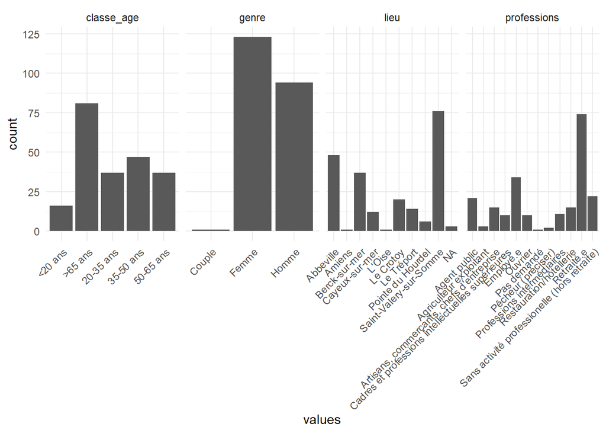

```r
p
```

**Q1 : Ecrivez le code pour plotter la variable `classe_age` avec `ggplot`**

### Code et indices

Indices :

- les datas sont elles `tidy` avec une seule variable?
- Pensez à utiliser la caractéristique `stat = count`

```r
p = data_ %>%
  ggplot(aes(x = classe_age))+
  geom_bar(stat= 'count')
```

### Plot

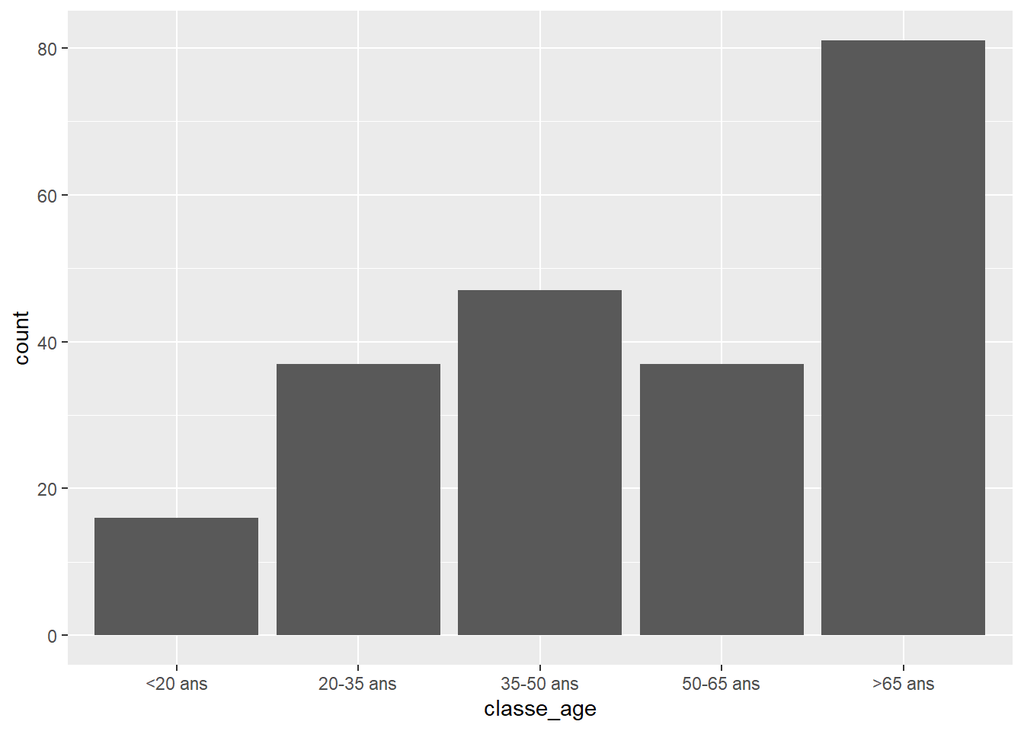

```r
p
```

Ce n’est pas très joli, ni modulaire : on va écrire une fonction

### Code

```r
library(RColorBrewer)

plot_distribution = function(variable, data = data_){

  if(!is.numeric(data[[variable]])){ # Check if binary or character
    stat_ = 'count'
  }else{
    stat_ = "bin"
  }
  data %>%
    ggplot(aes(x = get(variable), fill = get(variable)))+
    geom_histogram(stat = stat_)+
    xlab(variable)+
    labs(fill = ' ')+
    custom_theme()+
    scale_fill_brewer(palette = "Paired")
}
```

### Age

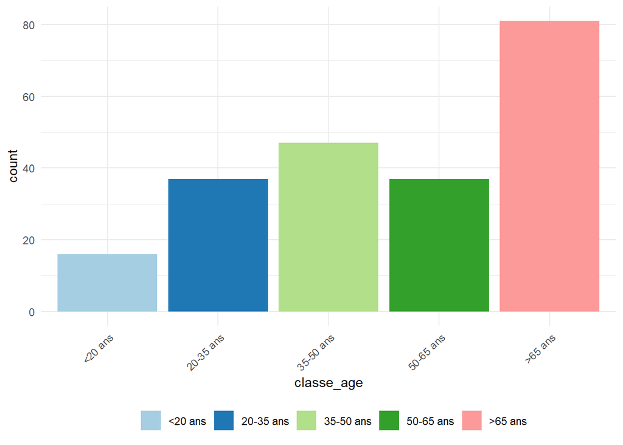

```r
plot_distribution("classe_age")
```

### Professions

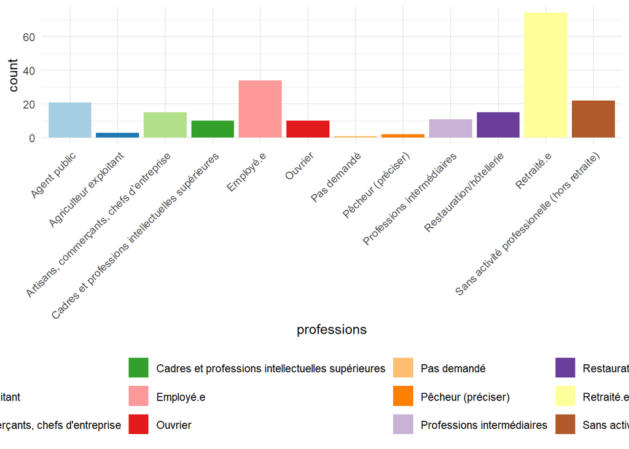

```r
plot_distribution("professions")
```

### Lieux

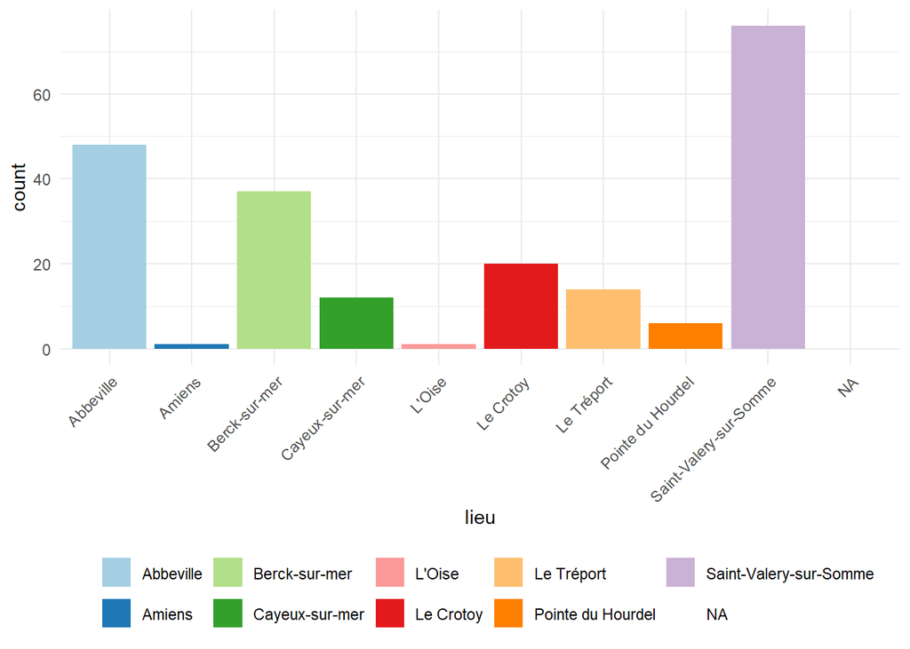

```r
plot_distribution("lieu")
```

## Population de phoques : noms

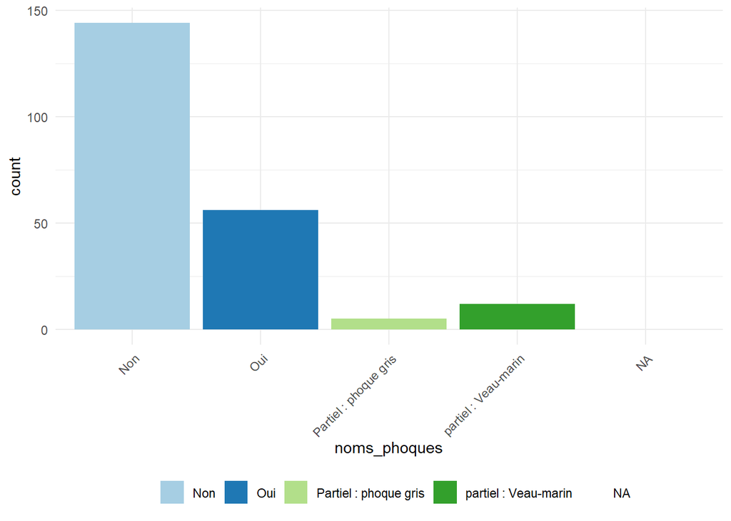

```r
plot_distribution("noms_phoques")
```

## Population de phoques

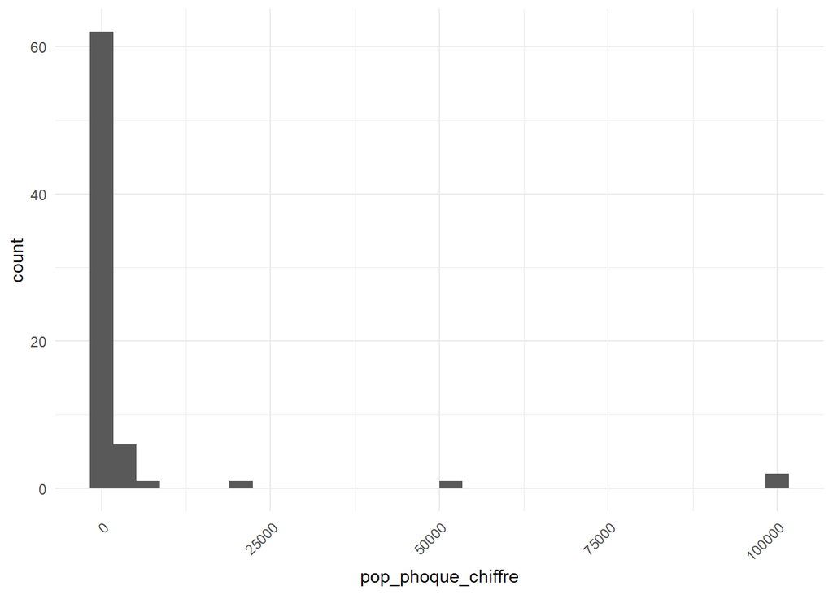

```r
plot_distribution("pop_phoque_chiffre")
```

### Phoques paisibles

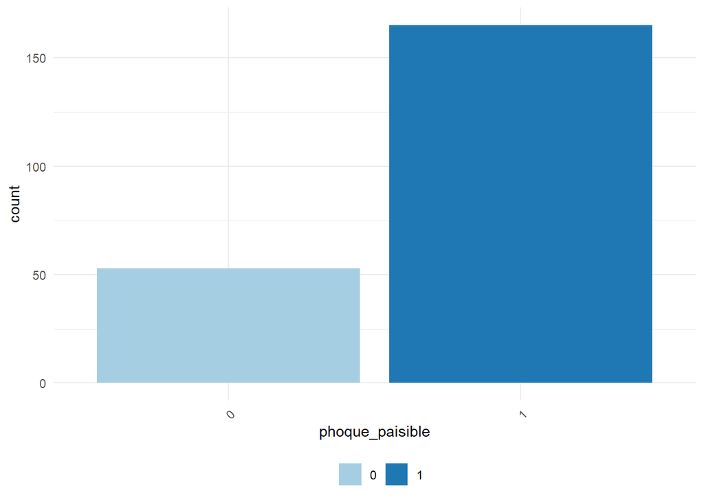

```r
plot_distribution("phoque_paisible")
```

### Invasifs et nuisibles

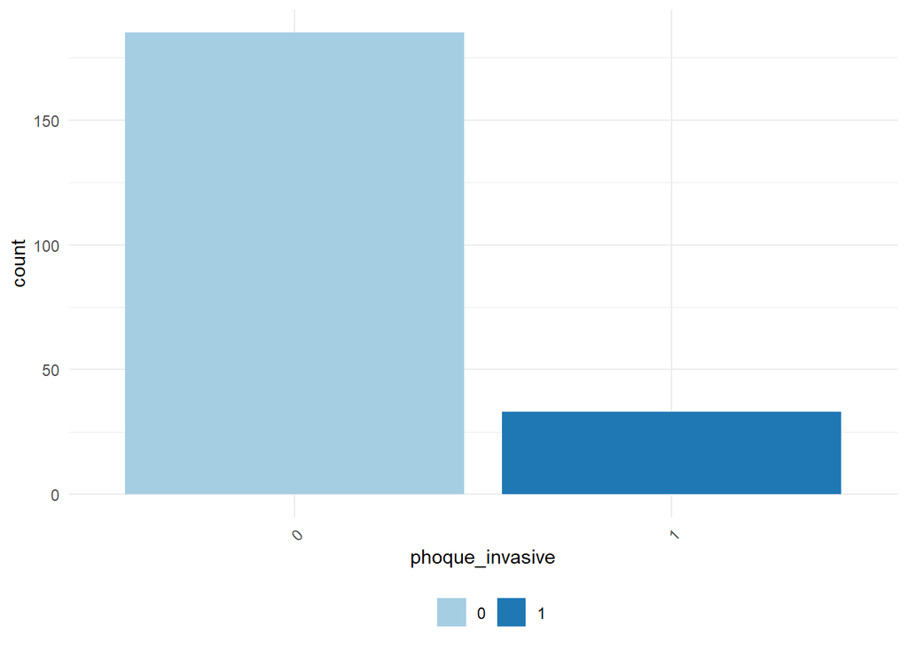

```r
plot_distribution("phoque_invasive")
```

### Concurrents

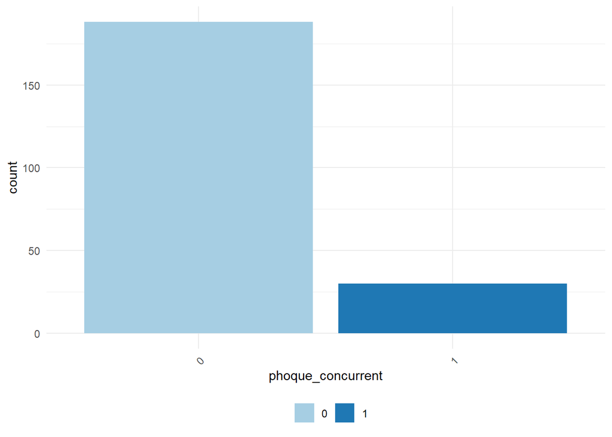

```r
plot_distribution("phoque_concurrent")
```

### Menacés

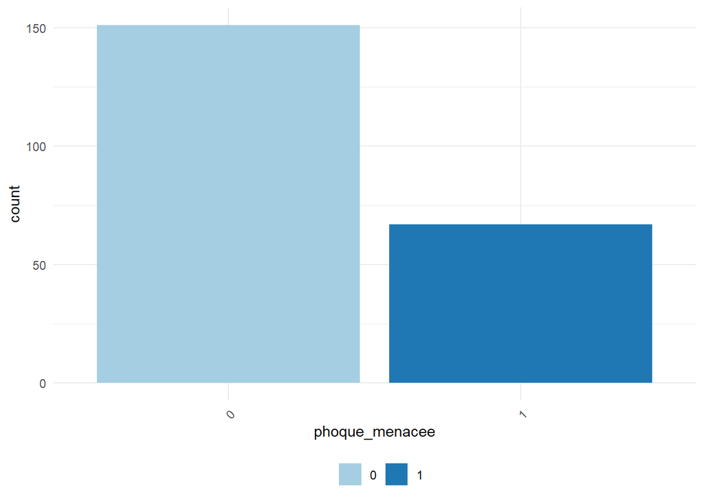

```r
plot_distribution("phoque_menacee")
```

### Prédateurs

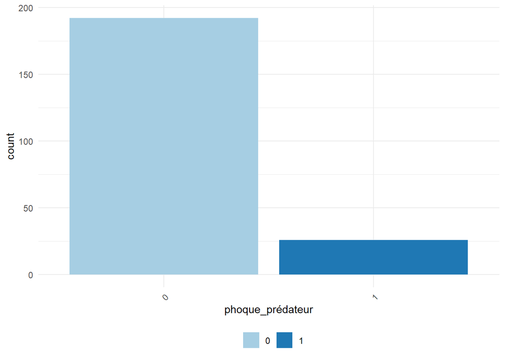

```r
plot_distribution("phoque_prédateur")
```

## Analyse bivariée

On cherche la répartition de notre échantillon entre classes d’âge et différente caractéristiques :

### Code

```r
p = data_ %>%
ggplot(aes(x = classe_age, fill = professions)) +
  geom_bar(position = "fill") +  # Normalized proportions
  theme_minimal()+
  scale_fill_brewer(palette = "Paired")
```

### Graphique

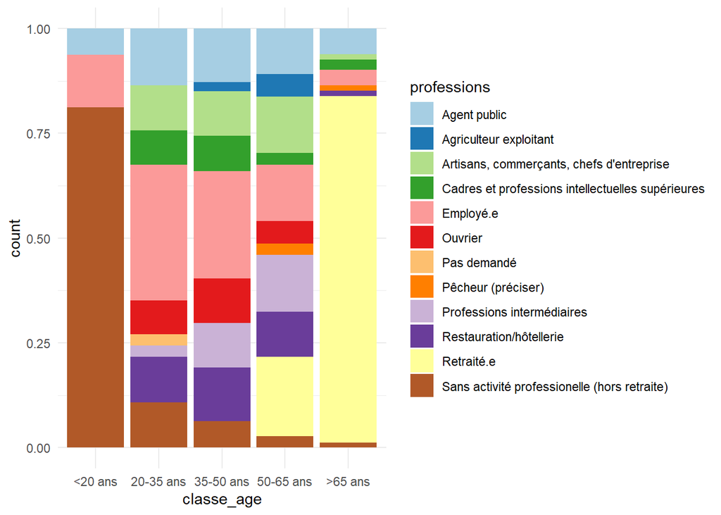

```r
p
```

## Analyse bivariée : phoques paisible et nature sauvage

**Q2 : plottez la correlation entre `phoque_paisible` et `q_nature_libre`**

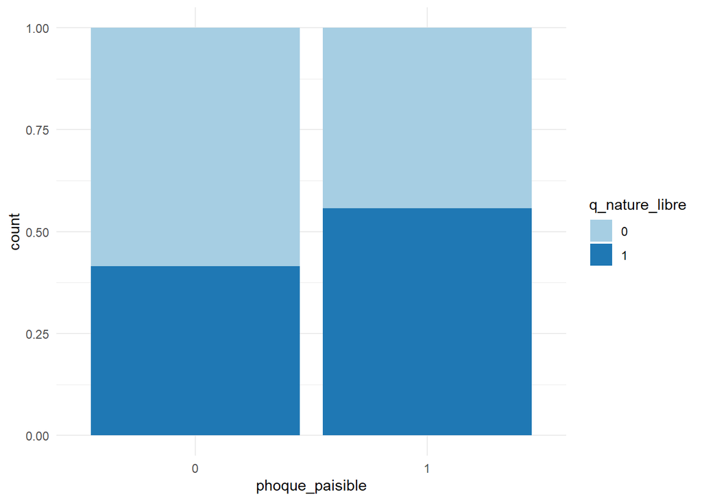

```r
data_ %>%
  ggplot(aes(x = phoque_paisible, fill = q_nature_libre)) +
  geom_bar(position = "fill") +  # Normalized proportions
  theme_minimal()+
  scale_fill_brewer(palette = "Paired")
```

## Analyse bivariée : phoques paisible et connaissance des phoques

**Q3 : plottez la correlation entre `phoque_paisible` et `pop_yes_no`**

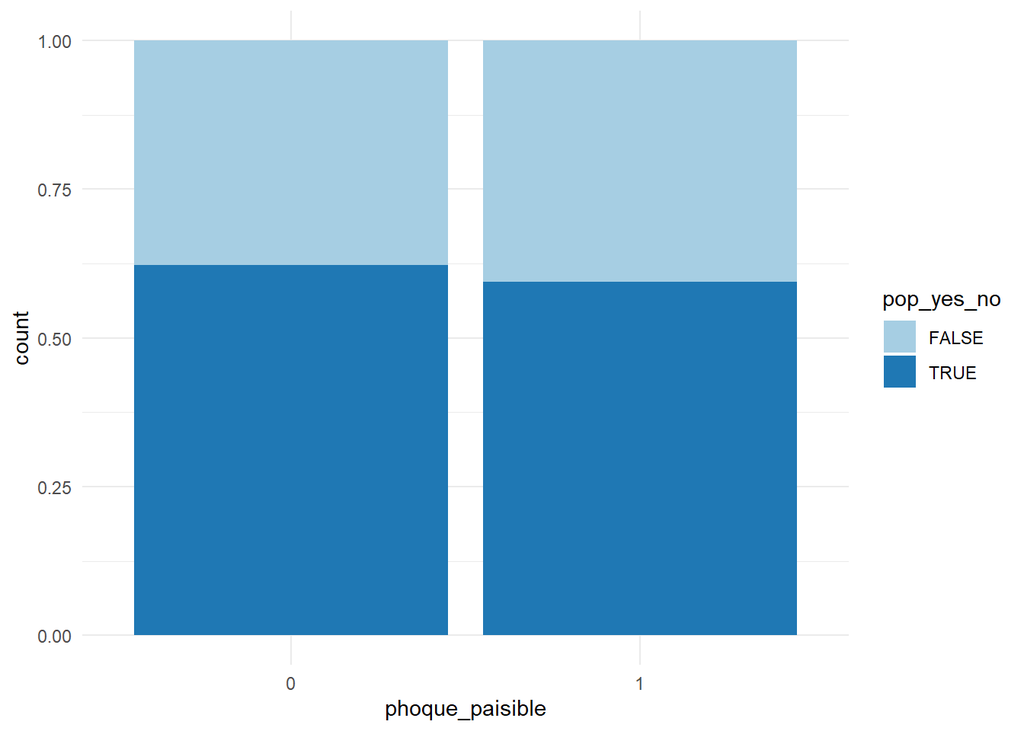

```r
data_ %>%
  ggplot(aes(x = phoque_paisible, fill = pop_yes_no)) +
  geom_bar(position = "fill") +  # Normalized proportions
  theme_minimal()+
  scale_fill_brewer(palette = "Paired")
```

## Analyses multivariées : global

### Code

```r
correlation_matrix = cor(data_ %>%
                           select(to_factor_vect)%>%
                           select(- c('wingfoil'))%>%
                           mutate(across(everything(), as.numeric)),
                         method = 'pearson')
```

```r
# On efface la diagonale (corrélation de 1) et on garde seulement un triangle pour éviter la redondance
diag(correlation_matrix) = NA

# Convert matrix to long format for ggplot
cor_long = reshape2::melt(correlation_matrix)

p = ggplot(cor_long, aes(Var1, Var2, fill = value)) +
  geom_tile() +
  scale_fill_gradient2(low = "blue", mid = "white", high = "red", midpoint = 0) +
  labs(title = "Correlation Heatmap of One-Hot Encoded Variables",
       x = " ",
       y = " ",
       fill = "Correlation") +
  theme_minimal() +
  theme(axis.text.x = element_text(angle = 45, hjust = 1))
```

### Heatmap de toutes les variables

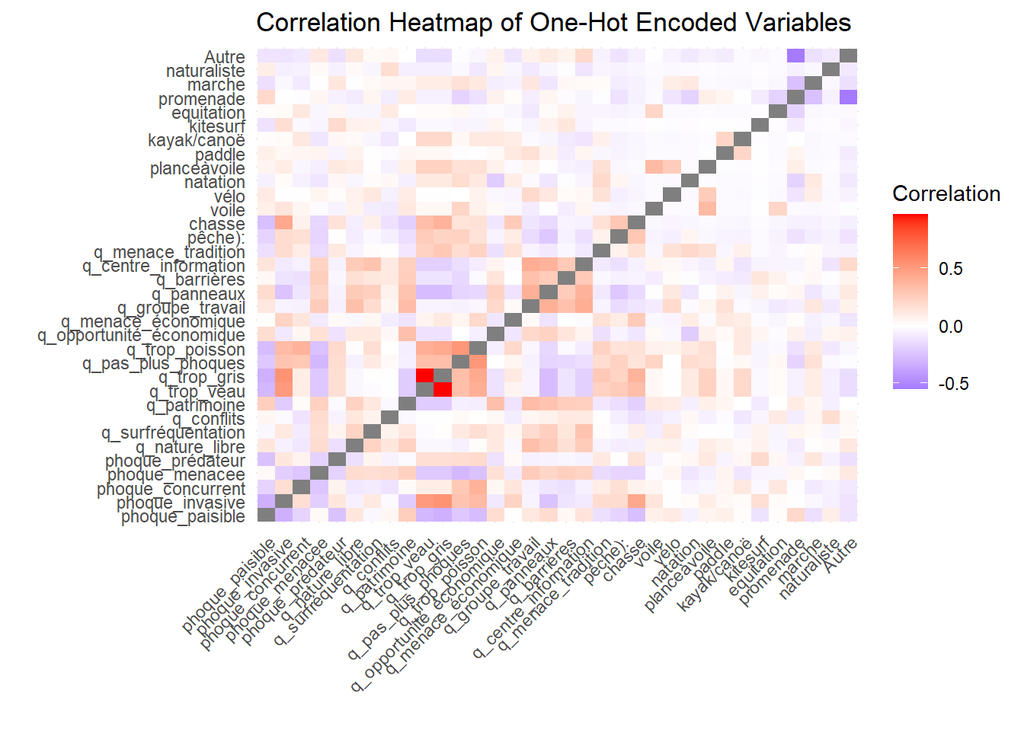

```r
p
```

## Analyse multivariée : restreinte

### Code

On va essayer de restreindre un peu l’analyse : Q4 : prenez un sous ensemble de variables, comme les caractéristiques des phoques et les réponses aux questions et faites une heatmap]{.bg}

```r
correlation_matrix = cor(data_ %>%
                           select(colnames(data_)[startsWith(colnames(data_), "q_")])%>%
                           mutate(across(everything(), as.numeric)),
                         method = 'pearson')

diag(correlation_matrix) = NA

# Convert matrix to long format for ggplot
cor_long = reshape2::melt(correlation_matrix)
```

### Graph

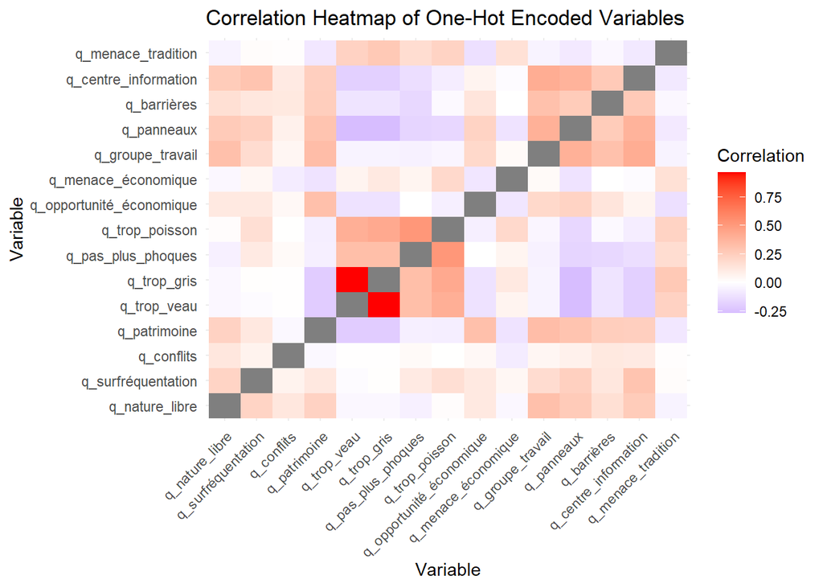

```r
ggplot(cor_long, aes(Var1, Var2, fill = value)) +
  geom_tile() +
  scale_fill_gradient2(low = "blue", mid = "white", high = "red", midpoint = 0) +
  labs(title = "Correlation Heatmap of One-Hot Encoded Variables",
       x = "Variable",
       y = "Variable",
       fill = "Correlation") +
  theme_minimal() +
  theme(axis.text.x = element_text(angle = 45, hjust = 1))
```

# Analyse par correspondance multiple

Technique d’analyse multivariées pour identifier la structure d’un espace de grande dimension

## Origine et développement

- Jean-Paul Benzécri (années 1960) :
  - Pionnier de l’analyse des correspondances, il développe l’Analyse des Correspondances Simples (ACS) pour représenter graphiquement la structure des tableaux de contingence.
  - Nécessité de visualiser les relations entre catégories dans des enquêtes sociales, marketing, etc.
  - Extension vers l’Analyse des Correspondances Multiples (ACM)
  - Adaptation de l’ACS pour traiter simultanément plusieurs variables qualitatives, en combinant plusieurs tableaux de contingence dans une matrice globale.
- Harold Hotelling ]{.bg} (années 1930-1940) :
  - Pionnier de l’Analyse en Composantes Principales (ACP), il formalise la réduction de dimensionnalité pour des variables quantitatives.
  - Introduit l’idée de décomposition en valeurs propres, qui vise à extraire des axes expliquant la plus grande part de la variance.
- Théorie de l’information et géométrie
  - L’inertie (ou dispersion) dans les données est mesurée de manière similaire à la variance en ACP, ce qui permet de comparer et de représenter les structures des données.

## Intuition mathématique – De la géométrie à la décomposition

- Principe de base : représentation géométrique]{.bg}
  - Chaque individu est représenté par un point dans un espace de dimension élevée, chaque axe correspondant à une modalité (catégorie).
  - Objectif : trouver un espace de dimension réduite qui capture l’essentiel des relations entre modalités et individus
- Mesure de la dispersion : l’inertie]{.bg}
  - Inertie totale : analogue à la variance en ACP, elle mesure la dispersion totale des points par rapport au centre.
  - Chaque modalité contribue à cette inertie selon sa fréquence et son écart par rapport à l’attendu en cas d’indépendance.
- Décomposition en valeurs singulières (SVD) ]{.bg}
  - Inspirée par l’ACP de Hotelling, la SVD permet de décomposer la matrice normalisée en axes factoriels orthogonaux.
  - La SVD « fait pivoter » l’espace initial pour révéler les directions (axes) où la dispersion (l’information) est maximale.
  - Les axes sélectionnés expliquent successivement des parts décroissantes de l’inertie totale.

## Fonctionnement pas à pas – De la donnée brute à l’interprétation

- Préparation des données : construction d’un tableau binaire :]{.bg}
  - Chaque individu est décrit par des réponses qualitatives, transformées en indicateurs (1 ou 0) pour chaque modalité.
- Normalisation et calcul des distances]{.bg}
  - Utilisation de la distance du khi-deux, adaptée aux données qualitatives, pour mesurer la similitude entre profils.
  - Pondération des modalités selon leur fréquence pour équilibrer leur influence.
- Décomposition via SVD]{.bg}
  - La matrice normalisée est décomposée en composantes grâce à la SVD, qui découle directement des idées de réduction de dimensionnalité portées par l’ACP de Hotelling.
  - Chaque axe factoriel est associé à une valeur propre qui quantifie la part d’inertie expliquée.
- Projection et interprétation]{.bg}
  - Projection simultanée des individus et des modalités sur les axes factoriels.
  - Les points proches indiquent des profils similaires.
  - Les axes traduisent des tendances ou oppositions sous-jacentes (ex. profils traditionnels vs. profils modernes).

## Idée générale

- On minimise la distance du khi-deux intra-classe : les modalités proches doivent rester proches]{.bg}
- On maximise la dispersion entre groupes distincts: les modalités et individus différents doivent être bien séparés sur les axes factoriels.

## Mise en pratique

- Il faut préparer les données: on ne va pas tout garder
- Par ailleurs, la structure de nos questions n’est pas parfaite pour utiliser l’ACM :
  - Fait pour quand plusieurs niveaux d’une même question sont mutuellement exclusifs
  - Nous, on a autorisé 2 ou 5 réponses par question(s)
  - On n’a pas exactement la même structure, donc la distance du khi-deux risque d’être un peu modifiée
  - On pourrait modifier les réponses et les pondérer par le nombre de réponses
- Malgré ces problèmes, on va illustrer la méthode : on réfléchira ensuite à la meilleure manière
- Pour cela on utilise les bibliothèques `FactoMineR` et `factoextra`

```r
library(FactoMineR)
library(factoextra)

# I. Préparer les données : il faut que des facteurs

data_for_analysis = data_%>%
  select(c(to_factor_vect, 'genre', 'classe_age', 'pop_yes_no', 'professions', 'noms_phoques'))%>%
   mutate(across(everything(), as.factor))%>%
  drop_na()
```

## Réaliser l’ACM

- La fonction `MCA()` va :
  - Construire le tableau disjonctif complet.
    - Calculer la distance du khi-deux pour chaque individu et modalité.
    - Réaliser la décomposition en valeurs singulières qui, de manière implicite, minimise la somme des distances (c’est-à-dire l’inertie non expliquée).
- On enlève les modalités les plus corrélées

```r
cor_threshold <- 0.5
cor_pairs <- which(abs(correlation_matrix) > cor_threshold, arr.ind = TRUE)

# Remove the diagonal (where row and column are the same)
cor_pairs <- cor_pairs[cor_pairs[, 1] != cor_pairs[, 2], ]

# Get the variable names for the pairs
pair_names <- apply(cor_pairs, 1, function(x) paste(rownames(correlation_matrix)[x[1]], "-", colnames(correlation_matrix)[x[2]]))

# Print the pairs
print(pair_names)
```

```
##                           q_trop_gris                           q_trop_veau
##           "q_trop_gris - q_trop_veau"           "q_trop_veau - q_trop_gris"
##                        q_trop_poisson                    q_pas_plus_phoques
## "q_trop_poisson - q_pas_plus_phoques" "q_pas_plus_phoques - q_trop_poisson"
```

```r
res.mca <- MCA(data_for_analysis%>%
                 select(-c('classe_age', 'pop_yes_no', 'professions', 'noms_phoques',
                           'q_trop_veau', 'q_pas_plus_phoques')),
               graph = FALSE)
```

## Visualiser les résultats

On va visualiser le scree plot qui montre la part de variance expliquée par chaque axe factoriel

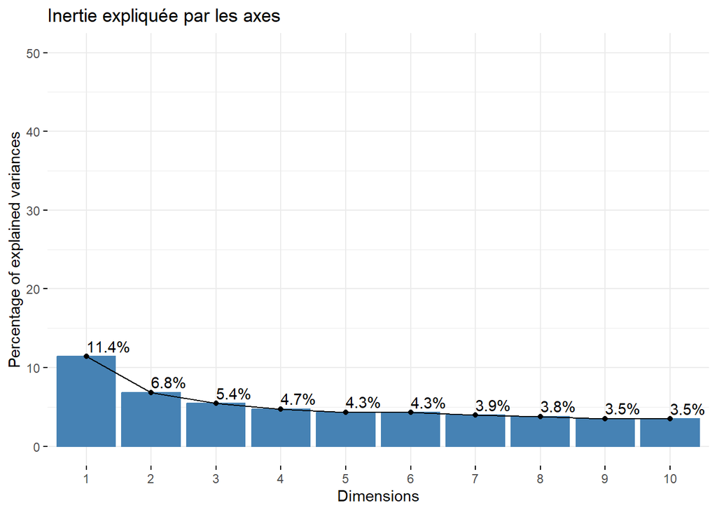

```r
fviz_screeplot(res.mca, addlabels = TRUE, ylim = c(0, 50),
               title = "Inertie expliquée par les axes")
```

## Visualisation des individus et des modalités

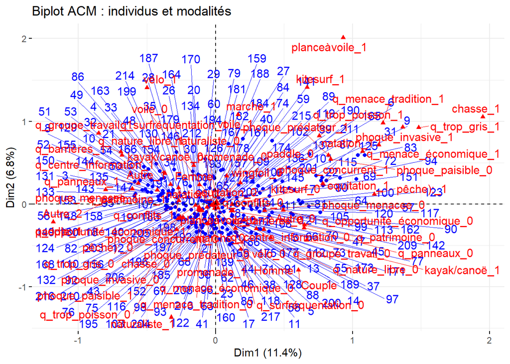

```r
fviz_mca_biplot(res.mca,
                repel = TRUE,
                title = "Biplot ACM : individus et modalités")
```

## Visualisation des modalités

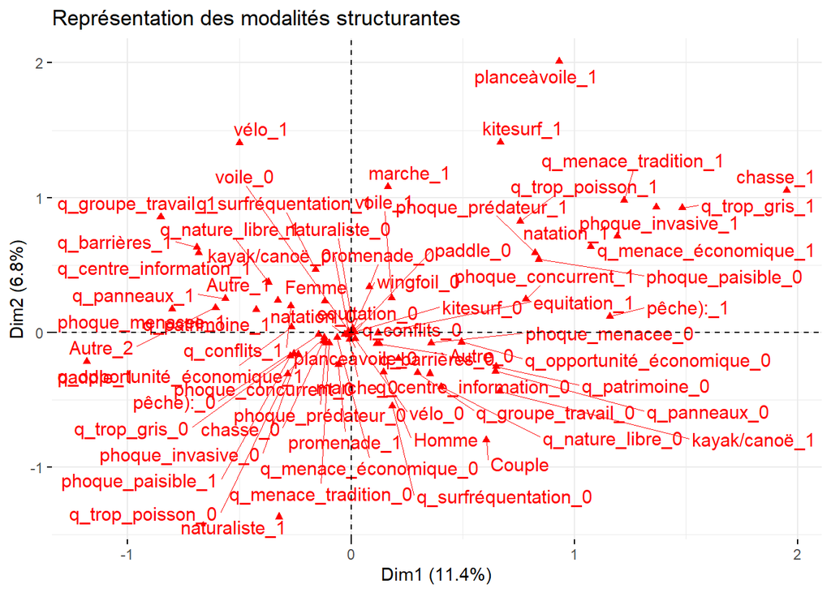

```r
fviz_mca_var(res.mca,
             repel = TRUE,           # Évite les chevauchements de textes
             title = "Représentation des modalités structurantes")
```

## Visualisation des modalités restreintes

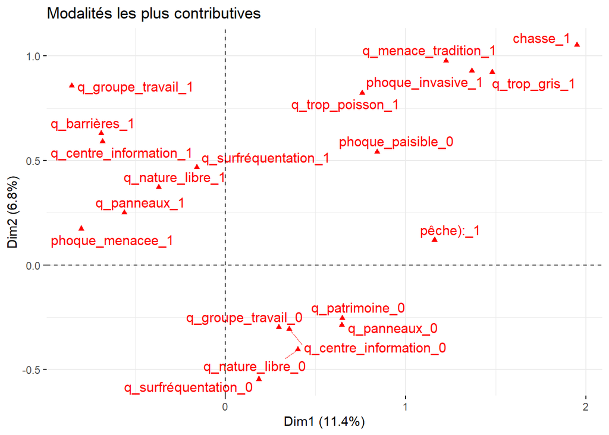

```r
fviz_mca_var(res.mca,
             repel = TRUE,
             select = list(contrib = 20),  # Affiche les 20 modalités les plus contributives
             title = "Modalités les plus contributives")
```

## Visualisation des modalités restreintes

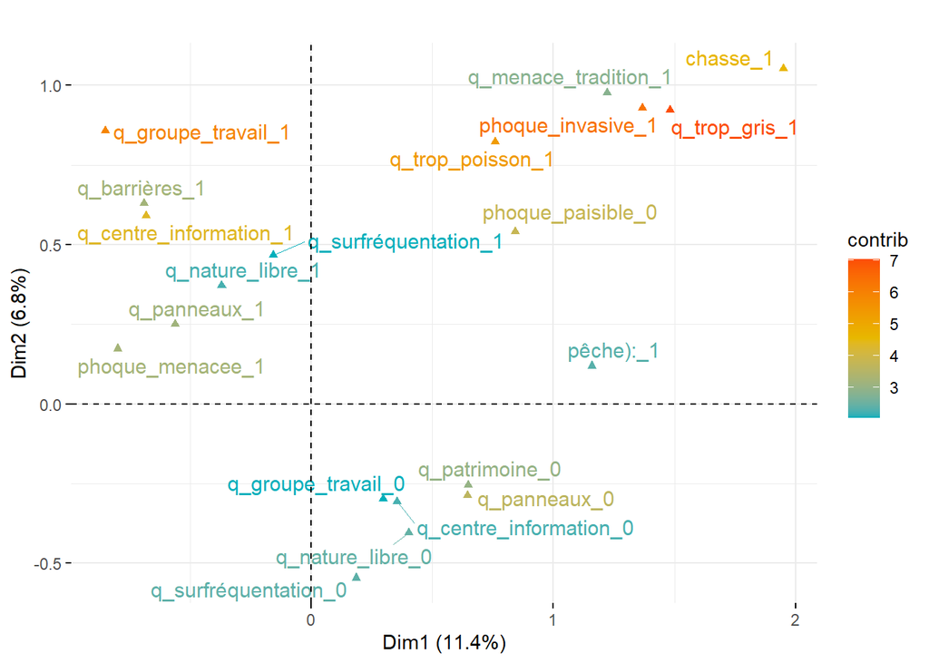

```r
fviz_mca_var(res.mca, col.var = "contrib",
             gradient.cols = c("#00AFBB", "#E7B800", "#FC4E07"),
             select = list(contrib = 20),  # Affiche les 20 modalités les plus contributives
             repel = TRUE, # avoid text overlapping (slow)
             ggtheme = theme_minimal(), title= " ",
)
```

# Visualisation des individus

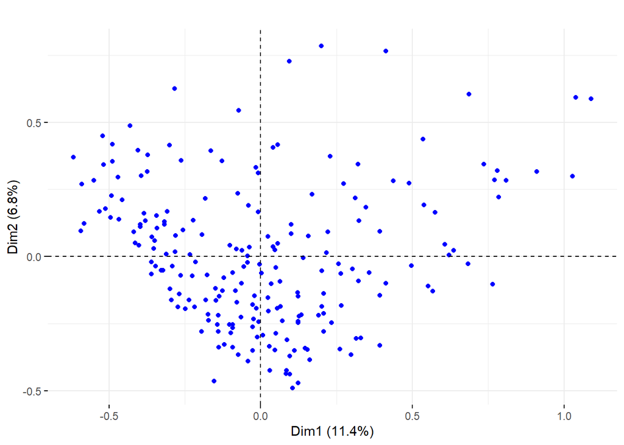

```r
fviz_mca_ind(res.mca,
             label = "none", # masquer le texte des individus
             ggtheme = theme_minimal (),
             title=" ")
```

## Visualisation des individus avec classes d’age

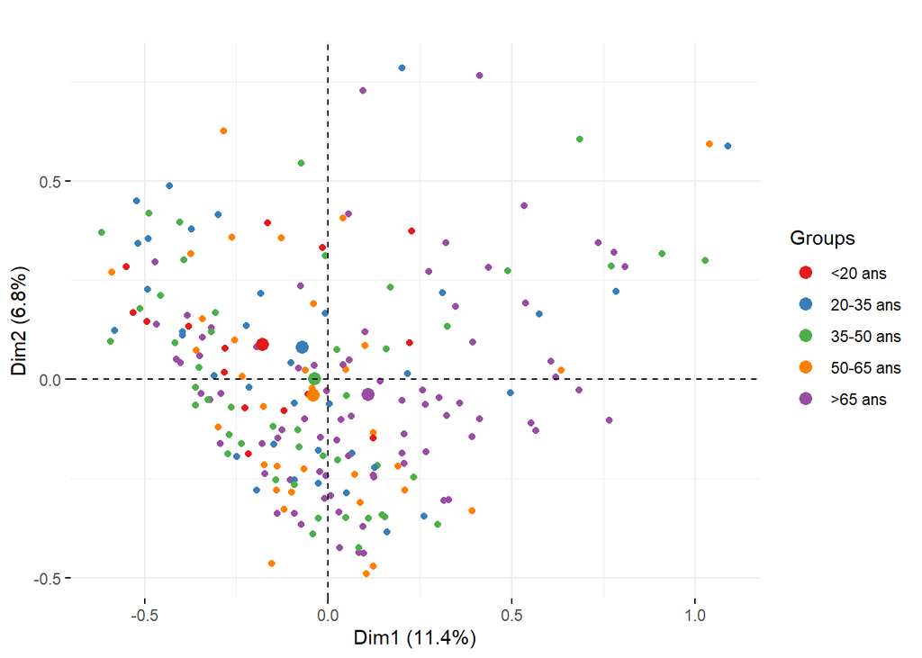

```r
palette_5 <- c("#E41A1C", "#377EB8", "#4DAF4A", "#FF7F00", "#984EA3")


fviz_mca_ind(res.mca,
             label = "none", # masquer le texte des individus
             ggtheme = theme_minimal (),
             palette = palette_5,
             habillage = data_for_analysis$classe_age,
             title=" ")
```

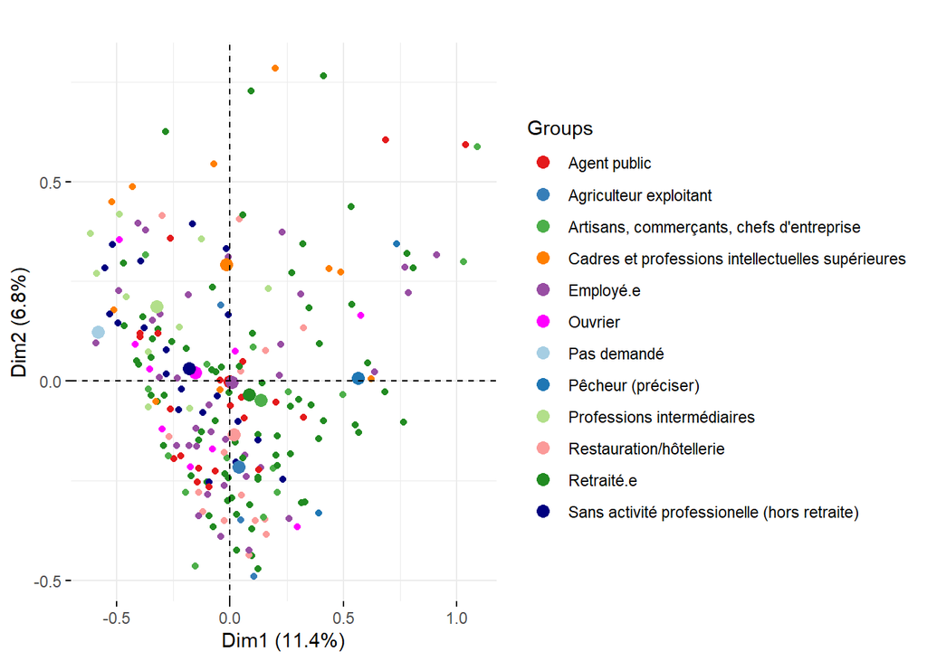

```r
palette_11 <- c("#E41A1C", "#377EB8", "#4DAF4A", "#FF7F00", "#984EA3",
                "#FF00FF", "#A6CEE3", "#1F77B4", "#B2DF8A", "#FB9A99", "forestgreen", "navyblue")

fviz_mca_ind(res.mca,
             label = "none", # masquer le texte des individus
             ggtheme = theme_minimal (),
             palette = palette_11,
             habillage = data_for_analysis$profession,
             title=" ")
```